# Project 2: Patients Appointments Data Analysis

- Introduction
- Data Wrangling
- Exploratory Data Analysis
- Conclusions

## Introduction

```python
import pandas as pd
import numpy as np
import matplotlib.pyplot as plt
import seaborn as sns
%matplotlib inline
```

## Data Wrangling

### General Properties

```python
# Loading my data and printing out a few lines.
df= pd.read_csv('noshowappt.csv')
df.head(2)
```

|  | PatientId | AppointmentID | Gender | ScheduledDay | AppointmentDay | Age | Neighbourhood | Scholarship | Hipertension | Diabetes | Alcoholism | Handcap | SMS_received | No-show |
| --- | --- | --- | --- | --- | --- | --- | --- | --- | --- | --- | --- | --- | --- | --- |
| 0 | 2.987250e+13 | 5642903 | F | 2016-04-29T18:38:08Z | 2016-04-29T00:00:00Z | 62 | JARDIM DA PENHA | 0 | 1 | 0 | 0 | 0 | 0 | No |
| 1 | 5.589978e+14 | 5642503 | M | 2016-04-29T16:08:27Z | 2016-04-29T00:00:00Z | 56 | JARDIM DA PENHA | 0 | 0 | 0 | 0 | 0 | 0 | No |

```python
df.describe()
```

|  | PatientId | AppointmentID | Age | Scholarship | Hipertension | Diabetes | Alcoholism | Handcap | SMS_received |
| --- | --- | --- | --- | --- | --- | --- | --- | --- | --- |
| count | 1.105270e+05 | 1.105270e+05 | 110527.000000 | 110527.000000 | 110527.000000 | 110527.000000 | 110527.000000 | 110527.000000 | 110527.000000 |
| mean | 1.474963e+14 | 5.675305e+06 | 37.088874 | 0.098266 | 0.197246 | 0.071865 | 0.030400 | 0.022248 | 0.321026 |
| std | 2.560949e+14 | 7.129575e+04 | 23.110205 | 0.297675 | 0.397921 | 0.258265 | 0.171686 | 0.161543 | 0.466873 |
| min | 3.921784e+04 | 5.030230e+06 | -1.000000 | 0.000000 | 0.000000 | 0.000000 | 0.000000 | 0.000000 | 0.000000 |
| 25% | 4.172614e+12 | 5.640286e+06 | 18.000000 | 0.000000 | 0.000000 | 0.000000 | 0.000000 | 0.000000 | 0.000000 |
| 50% | 3.173184e+13 | 5.680573e+06 | 37.000000 | 0.000000 | 0.000000 | 0.000000 | 0.000000 | 0.000000 | 0.000000 |
| 75% | 9.439172e+13 | 5.725524e+06 | 55.000000 | 0.000000 | 0.000000 | 0.000000 | 0.000000 | 0.000000 | 1.000000 |
| max | 9.999816e+14 | 5.790484e+06 | 115.000000 | 1.000000 | 1.000000 | 1.000000 | 1.000000 | 4.000000 | 1.000000 |

- from the describtive above, It is clear that there are 110527 patients. I noticed some illogical informations like a negative age. There are old patients such that the maximum age is 115 but they are few since 75% of patients are bellow 55 years, so the majority is between (0-55) yrs old.

```python
df.query('Age <=0').count()
# Since (3540) 3% of the data has a not realistic ages, they will be dropped
```

```
PatientId         3540
AppointmentID     3540
Gender            3540
ScheduledDay      3540
AppointmentDay    3540
Age               3540
Neighbourhood     3540
Scholarship       3540
Hipertension      3540
Diabetes          3540
Alcoholism        3540
Handcap           3540
SMS_received      3540
No-show           3540
dtype: int64
```

```python
# Only keep ages that are greater than 0.
df = df[df['Age'] > 0 ]
```

```python
# Check the changes
df.describe()
```

|  | PatientId | AppointmentID | Age | Scholarship | Hipertension | Diabetes | Alcoholism | Handcap | SMS_received |
| --- | --- | --- | --- | --- | --- | --- | --- | --- | --- |
| count | 1.069870e+05 | 1.069870e+05 | 106987.000000 | 106987.000000 | 106987.000000 | 106987.000000 | 106987.000000 | 106987.000000 | 106987.000000 |
| mean | 1.472814e+14 | 5.675434e+06 | 38.316085 | 0.101031 | 0.203772 | 0.074243 | 0.031406 | 0.022975 | 0.323264 |
| std | 2.558267e+14 | 7.133274e+04 | 22.466214 | 0.301371 | 0.402804 | 0.262167 | 0.174412 | 0.164115 | 0.467725 |
| min | 3.921784e+04 | 5.030230e+06 | 1.000000 | 0.000000 | 0.000000 | 0.000000 | 0.000000 | 0.000000 | 0.000000 |
| 25% | 4.173523e+12 | 5.640490e+06 | 19.000000 | 0.000000 | 0.000000 | 0.000000 | 0.000000 | 0.000000 | 0.000000 |
| 50% | 3.172463e+13 | 5.680744e+06 | 38.000000 | 0.000000 | 0.000000 | 0.000000 | 0.000000 | 0.000000 | 0.000000 |
| 75% | 9.433600e+13 | 5.725634e+06 | 56.000000 | 0.000000 | 0.000000 | 0.000000 | 0.000000 | 0.000000 | 1.000000 |
| max | 9.999816e+14 | 5.790484e+06 | 115.000000 | 1.000000 | 1.000000 | 1.000000 | 1.000000 | 4.000000 | 1.000000 |

- minimum age is 1

```python
df.shape
```

```
(106987, 14)
```

- There are 106987 patients and 14 characteristics

```python
# Check for duplicated rows.
df.duplicated().sum()
```

```
0
```

We have no duplicates.

### Data Cleaning by removing Unnecessary columns and renaming

```python
# Change the '-' in the column No-show into an underscore '_' because it's easier for me to deal with
df.rename(columns={'No-show':'No_show'}, inplace=True)
```

```python
# drop columns that will not be used Throughout the analysis
df.drop(['PatientId', 'AppointmentID', 'ScheduledDay','AppointmentDay','Neighbourhood'], axis=1, inplace=True)
```

```python
#check the changes after Modifying.
df.columns
```

```
Index(['Gender', 'Age', 'Scholarship', 'Hipertension', 'Diabetes',
       'Alcoholism', 'Handcap', 'SMS_received', 'No_show'],
      dtype='object')
```

```python
# Use info to check if any column has missing values also check the data types if they are appropriate.
df.info()
```

```
<class 'pandas.core.frame.DataFrame'>
Int64Index: 106987 entries, 0 to 110526
Data columns (total 9 columns):
 #   Column        Non-Null Count   Dtype
---  ------        --------------   -----
 0   Gender        106987 non-null  object
 1   Age           106987 non-null  int64
 2   Scholarship   106987 non-null  int64
 3   Hipertension  106987 non-null  int64
 4   Diabetes      106987 non-null  int64
 5   Alcoholism    106987 non-null  int64
 6   Handcap       106987 non-null  int64
 7   SMS_received  106987 non-null  int64
 8   No_show       106987 non-null  object
dtypes: int64(7), object(2)
memory usage: 8.2+ MB
```

- The dataset has no missing values (nulls) and all datatypes are appropriate.

```python
df.shape
```

```
(106987, 9)
```

```python
# Find number of patients who have any one of these Characteristics.
print(df['Scholarship'].sum())
print(df['Hipertension'].sum())
print(df['Diabetes'].sum())
print(df['Alcoholism'].sum())
print(df['Handcap'].sum())
```

```
10809
21801
7943
3360
2458
```

- 10809 of total 106987 patients are enrolled in Brasilian welfare program "have scholarships" (Approximately 10% of the total patient).
- 21801 Patients have Hipertension "20% of patients, which is a high rate".
- It's clean that 7943 patients are diabetic i.e 7% of the total patients and it is relatively low.
- Patients with alcoholism and handicap and few regarding to. the total number of patients which is 3% for alcoholisim and 2% for handcap.

```python
# Total number of SMS's received by patients.
df['SMS_received'].sum()
```

```
34585
```

```python
# Total patients who showed and not showed.
df.No_show.value_counts()
#print(df.query('No_show =="No"').count())
```

```
No     85307
Yes    21680
Name: No_show, dtype: int64
```

85307 patients showed to their appointment which is approximately 80% of total patients.

```python
# Number of female patients
df.Gender.value_counts()
#print(df.query('Gender=="F"').count())
```

```
F    70118
M    36869
Name: Gender, dtype: int64
```

Female patients are 65.5% of total patients, while males only represent 34.5% of patients.

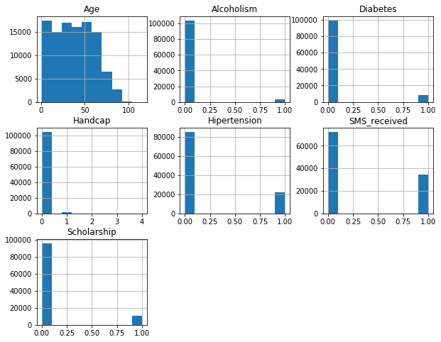

```python
df.hist(figsize=(10,8));
```

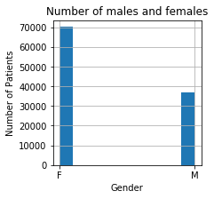

```python
#Histogram for Gender
df['Gender'].hist(figsize=(3,3), label='Gender').set_ylabel('Number of Patients');
plt.xlabel('Gender')
plt.title('Number of males and females');
```

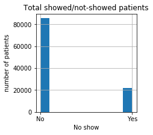

```python
# Histogram for not showed patients.
df['No_show'].hist(figsize=(3,3));
plt.ylabel('number of patients')
plt.xlabel('No show')
plt.title('Total showed/not-showed patients');
```

- It's clear that female patients are more than the males and most of the patients showed to their appointments.

### Now, I have a clear visualisation about my data and I am sure that my dataset is clean and organized to start my analysis.

## Exploratory Data Analysis

### Research Question :

### "What factors are important for us to know in order to predict if a patient will show up for their scheduled appointment?"

- FIND THE RELATIONSHIP BETWEEN **NO_SHOW** PATIENTS ARE THE OTHER CHARACTERISTICS AND CHECK IF ANY OF THEM AFFECTS THE ATTENDANCE.

```python
df.groupby(['No_show']).sum()
```

| No_show | Age | Scholarship | Hipertension | Diabetes | Alcoholism | Handcap | SMS_received |
| --- | --- | --- | --- | --- | --- | --- | --- |
| No | 3333387 | 8238 | 18029 | 6513 | 2683 | 2005 | 25017 |
| Yes | 765936 | 2571 | 3772 | 1430 | 677 | 453 | 9568 |

It is an overview of the relationship between showing up and the other charactarestics. We will analyse it in details in the coming steps:

###### 1-Does receiving SMS's increse the Probability of attending the appointment?

```python
# seperate the recieved messages from the not received ones.
received= df.SMS_received == True
not_received =df.SMS_received == False
```

```python
df.No_show[received].value_counts()
```

```
No     25017
Yes     9568
Name: No_show, dtype: int64
```

```python
df.No_show[not_received].value_counts()
```

```
No     60290
Yes    12112
Name: No_show, dtype: int64
```

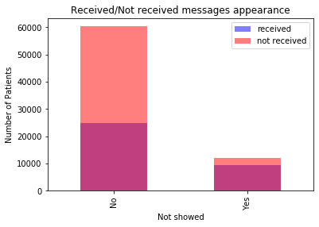

```python
df.No_show[received].value_counts().plot(alpha=0.5, kind='bar', color='blue', label='received')
df.No_show[not_received].value_counts().plot(alpha=0.5, kind='bar', color='red', label='not received')
plt.ylabel('Number of Patients')
plt.xlabel('Not showed')
plt.title('Received/Not received messages appearance')
plt.legend();
```

It is clear from the graph above that most patients show to their appointments whether they recieve a message or not.

###### 2- What Gender increses the Probability of showing to the appointment?

Number of males and females who showed who showed and didn't show:

```python
gend_show =df.groupby(['No_show'])['Gender'].value_counts()
gend_show
```

```
No_show  Gender
No       F         55843
         M         29464
Yes      F         14275
         M          7405
Name: Gender, dtype: int64
```

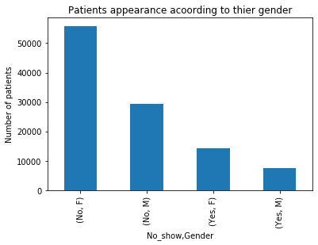

```python
gend_show.plot(kind='bar')
plt.title('Patients appearance acoording to thier gender')
plt.ylabel('Number of patients');
```

- 55843 of total 70118 females have showed to their appointments, approximately 80% of females. (very high percentage).
- For males, 29464 of total 36869 males showed to their appointments, 80% of total males which is also a high percentage!
- Since both males and females have the showing probability, we can not predict if a patient will show regarding to the gender.

###### 3- check if scholarship is associated with Attending the appointment

```python
scholarship = df.Scholarship == True
no_scholarship= df.Scholarship == False
```

```python
df.No_show[scholarship].value_counts()
```

```
No     8238
Yes    2571
Name: No_show, dtype: int64
```

```python
df.No_show[no_scholarship].value_counts()
```

```
No     77069
Yes    19109
Name: No_show, dtype: int64
```

8238 of total 10809 patients who have scholarship attend to the appointment (76% of the total, which means that most of people who have scholarship attend to their appointments), for the rest of patients who don't have scholarships, also must of them showed ( 77069 of total 96178 ) i.e. 80%. of patients, it is a high percentage as well. so must people show to the appointment whether they have a scholarship or not. We can predect that patients with scholarship will show, #but also most patient without scholarships also show.

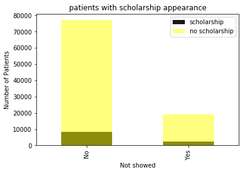

```python
df.No_show[scholarship].value_counts().plot(alpha=0.9, kind='bar', color='black', label='scholarship')
df.No_show[no_scholarship].value_counts().plot(alpha=0.5, kind='bar', color='yellow', label='no scholarship')
plt.ylabel('Number of Patients')
plt.xlabel('Not showed')
plt.title('patients with scholarship appearance')
plt.legend();
```

The graph shows and confirms what i have mentioned above.

###### 4- Find a relationship between patients with Hipertension (high blood pressure) and showing to the appointment

```python
high_bpressure = df.Hipertension == True
normal= df.Hipertension == False
```

```python
df.No_show[high_bpressure].value_counts()
```

```
No     18029
Yes     3772
Name: No_show, dtype: int64
```

```python
df.No_show[normal].value_counts()
```

```
No     67278
Yes    17908
Name: No_show, dtype: int64
```

In the data cleaning step we found that 21801 patients have a high blood pressure, 18029 of them showed to their appointment it means 83% of patients with Hipertension show in their appointments. For patients with no Hipertension, of total 85186 patients, 67278 of them showed to their appointment, the graph bellow helps us to visualize the results.

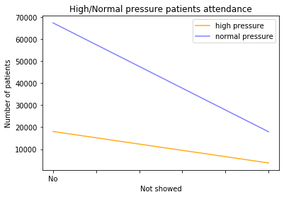

```python
df.No_show[high_bpressure].value_counts().plot(alpha=0.9, kind='line', color='orange', label='high pressure')
df.No_show[normal].value_counts().plot(alpha=0.5, kind='line', color='blue', label='normal pressure')
plt.xlabel('Not showed')
plt.ylabel('Number of patients')
plt.title('High/Normal pressure patients attendance')
plt.legend();
```

###### 5- Does having a Diabetes increse the Probability of showing to the appointment?

```python
diabetes = df.Diabetes == True
no_diabetes = df.Diabetes == False
```

```python
# check number of patients with diabetes who showed up to their appointment
df.No_show[diabetes].value_counts()
```

```
No     6513
Yes    1430
Name: No_show, dtype: int64
```

```python
# For patients without diabetes
df.No_show[no_diabetes].value_counts()
```

```
No     78794
Yes    20250
Name: No_show, dtype: int64
```

6513 patients with diabetes of total 7943 showed up for their scheduled appointment, about 82% of them so it is a high percentage and i can predect that a patient will show if he has diabetes.

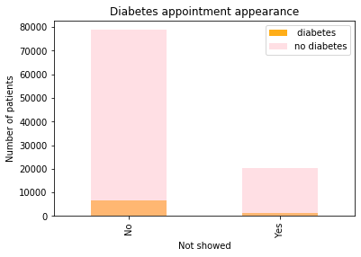

```python
df.No_show[diabetes].value_counts().plot(alpha=0.9, kind='bar', color='orange', label=' diabetes')
df.No_show[no_diabetes].value_counts().plot(alpha=0.5, kind='bar', color='pink', label='no diabetes')
plt.xlabel('Not showed')
plt.ylabel('Number of patients')
plt.title('Diabetes appointment appearance')
plt.legend();
```

patients with diabetes are few regarding to the total patients but we can say that if the patient is diabetes, he mostly will show.

###### 6- is Alcoholism associated with showing up to the appointment?

```python
alcoholism = df.Alcoholism == True
not_alcoholism = df.Alcoholism == False
```

```python
# check number of patients with diabetes who showed up to their appointment
df.No_show[alcoholism].value_counts()
```

```
No     2683
Yes     677
Name: No_show, dtype: int64
```

2683 patients of total 3360 (80%) of alcohol addicted showed up to their appointment. alcoholism represents about 3% of total patients, so alcoholism patients are few. but i can predect that if the patient is an alcohol addicted, he'll show up to the appointment.

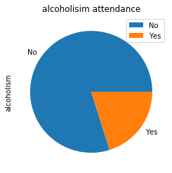

```python
df.No_show[alcoholism].value_counts().plot(kind='pie', label='alcoholism');
plt.title('alcoholisim attendance')
plt.legend();
```

The pie graph above also shows that most alcoholism shows up to their appointments.

###### 7- Does handicap patients show to their appointments?

From the data cleaning step, we found that Handicap patients represents less than 2.5% of total patients

```python
handicap = df.Handcap == True
no_handicap = df.Handcap == False
```

```python
df.No_show[handicap].value_counts()
```

```
No     1675
Yes     366
Name: No_show, dtype: int64
```

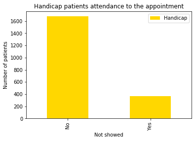

```python
# Graph for handicaps who showed up to their appointments
df.No_show[handicap].value_counts().plot( kind='bar', color='gold' ,label='Handicap')
plt.xlabel('Not showed')
plt.ylabel('Number of patients')
plt.title('Handicap patients attendance to the appointment')
plt.legend();
```

Well, yes most handicaps show up to their appointment, so we can predict if the patient will show up if he's a handicap

###### 8- showing up to the appointment regarding to the age.

Devide 'Age' into 4 different stages :

```python
kid= df['Age']<= 15
young= (df['Age'] <= 30) & (df['Age'] >15)
youth= (df['Age'] <= 55) & (df['Age'] >30)
old= df['Age'] > 55
```

How many patients showed ana didn't show in each stage:

```python
#For kids
df.No_show[kid].value_counts()
```

```
No     16320
Yes     4609
Name: No_show, dtype: int64
```

```python
#young
df.No_show[young].value_counts()
```

```
No     15921
Yes     5242
Name: No_show, dtype: int64
```

```python
#youth
df.No_show[youth].value_counts()
```

```
No     29865
Yes     7526
Name: No_show, dtype: int64
```

```python
# old
df.No_show[old].value_counts()
```

```
No     23201
Yes     4303
Name: No_show, dtype: int64
```

- For **kids** with total 20929, 16320 of them showed up i.e 78% of kids show up to their appointment.
- 15921 out of 21163 (75%) **young** patients shows to their appointment.
- For **youth**, 29865 out of 37391 patients came to their appointment i.e 80% of youth patients.
- For the **old** patients, 23201 out of 27504 (85%) of old patients attend their appointment. #### From the analysis, it's clear that most patients show up to their appointment, but old patients are more studious than the others.
- the graph bellow will make us visualize the analysis above clearly.

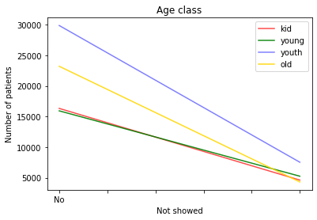

```python
df.No_show[kid].value_counts().plot(alpha=0.7, kind='line', color='red', label='kid')
df.No_show[young].value_counts().plot(alpha=0.9, kind='line', color='green', label='young')
df.No_show[youth].value_counts().plot(alpha=0.5, kind='line', color='blue', label='youth')
df.No_show[old].value_counts().plot(alpha=0.9, kind='line', color='gold', label='old')
plt.xlabel('Not showed')
plt.ylabel('Number of patients')
plt.title('Age class')
plt.legend();
```

it's clear that most patients in all ages show up to their appointment but since old patients has a higher percentage for showing so we will predect that old patients will show more than the others.

## Conclusions

> In my openion, if the dataset has informations about the distance between the hospital and where the patient lives it will be easer to predect that the patients who will show, the hospital is in or near to their hometown because sometimes it is hard for patients to travel and attend their appointments on time.